# Esquisse Data Visualization Lab - Key

First, make sure you install and load the `esquisse` package using `install.packages` and `library`:

```r
install.packages("esquisse")
```

```r
library(esquisse)
library(tidyverse)
```

### 1.1

Try creating a plot using the `Orange` data that automatically comes with R using the `esquisse` package.

- First take a look at the data in RStudio using `View()`.
- Drag and drop the `age` variable to be plotted on the x-axis.
- Drag and drop the `circumference` variable to be plotted on the y-axis.
- What happens when you drag `tree` to the facet region of the esquisse GUI?
- What happens if you move this to color?
- Copy and paste the code from both options into the chunk below:

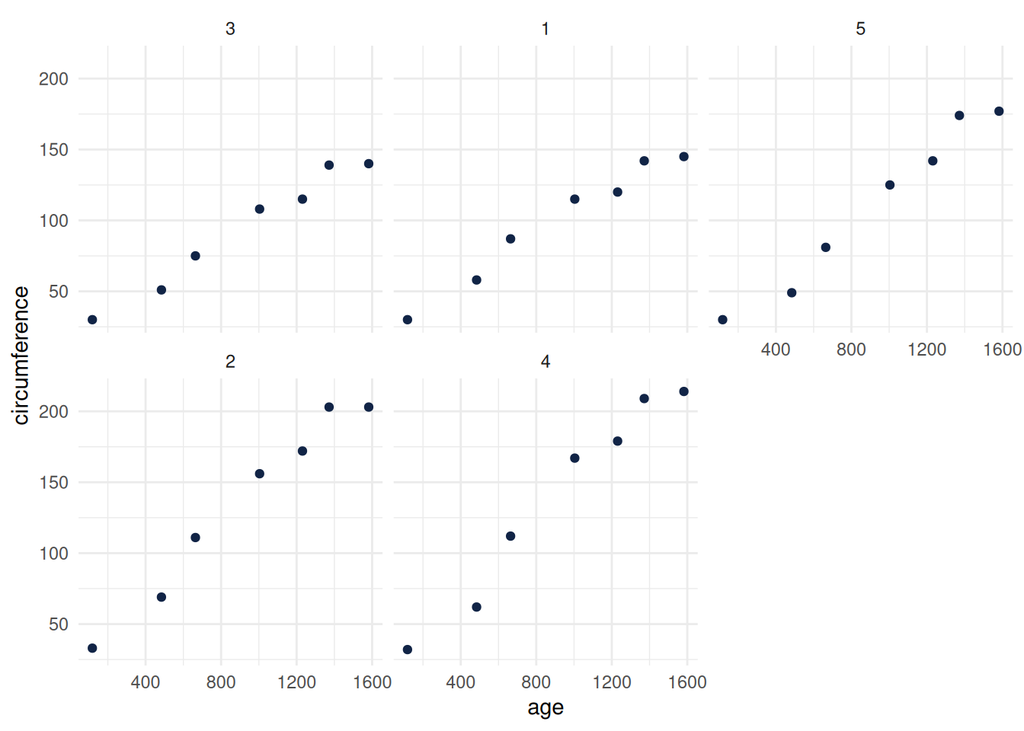

```r
# esquisser(Orange)
ggplot(Orange) +
  aes(x = age, y = circumference) +
  geom_point(shape = "circle", size = 1.5, colour = "#112446") +
  theme_minimal() +
  facet_wrap(vars(Tree))
```

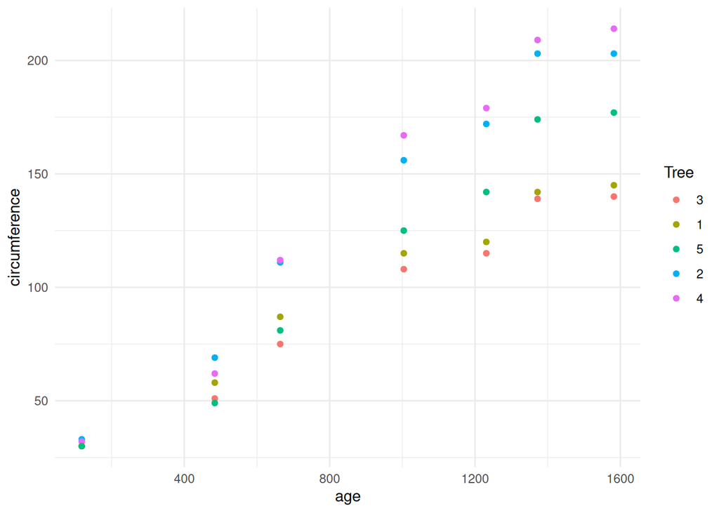

```r
ggplot(Orange) +
  aes(x = age, y = circumference, colour = Tree) +
  geom_point(shape = "circle", size = 1.5) +
  scale_color_hue(direction = 1) +
  theme_minimal()
```

### 1.2

Go back to your Esquisse window and click where it says “point” (may say “auto” depending on how you did the last question) on the far left side and change the plot to a different type of plot. Copy and paste the code into the chunk below. Close Esquisse and run the chunk below to generate a ggplot.

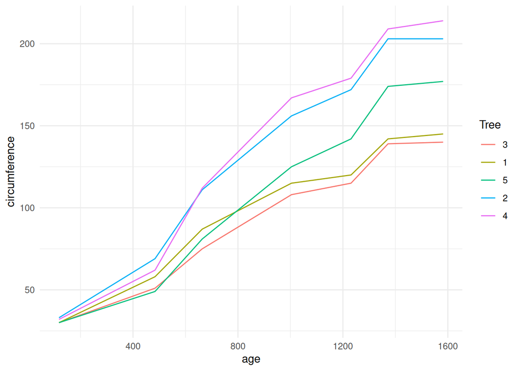

```r
ggplot(Orange) +
  aes(x = age, y = circumference, colour = Tree) +
  geom_line(size = 0.5) +
  scale_color_hue(direction = 1) +
  theme_minimal()
```

# Practice on Your Own!

### P.1

Launch Esquisse again on any selection of the following datasets we have worked with before and explore!

```r
yts <- read_csv("http://jhudatascience.org/intro_to_r/data/Youth_Tobacco_Survey_YTS_Data.csv")
tb <- read_csv("https://jhudatascience.org/intro_to_r/data/tb.csv")
bike <- read_csv(file = "http://jhudatascience.org/intro_to_r/data/Bike_Lanes.csv")
circ <- read_csv("https://jhudatascience.org/intro_to_r/data/Charm_City_Circulator_Ridership.csv")
vacc <- read_csv("http://jhudatascience.org/intro_to_r/data/USA_covid19_vaccinations.csv")
# esquisser(vacc)
```